# Pandas-Bootcamp-Part10

#### Handling Time and Date

- datetime foundations in Python and Numpy
- the Pandas timestamp and Datetime index
- up and downsampling with resample() and asfreq()
- interpolation and Aggregation
- Rolling Windows and Moving Averages

#### The Python datetime Module

datetime is a module that comes with Python Standard Library. datetime is used to manipulate dates and times.

```python
#from datetime module import the date class
from datetime import date
```

A date is characterized by year-month and day

```python
#create date object
#date(year,month,day)
date_A = date(2020 , 4 , 25)
```

```python
date_A
```

```
datetime.date(2020, 4, 25)
```

```python
type(date_A)
```

```
datetime.date
```

#### Why do we need a datetime object

But why not store dates like this :

```python
A = "2020 , 4 , 25"
```

Because date objects are easily manipulated . This is not possible with Strings. Strings will not have date manipulating functionality.

- If we need to know how many seconds there are between two random dates that are 15 days apart. This is not possible with strings.

#### Lets explore some date Attributes

```python
#create date object
#date(year,month,day)
date_A = date(2020 , 4 , 25)
```

```python
date_A.day
```

```
25
```

```python
date_A.year
```

```
2020
```

```python
date_A.month
```

```
4
```

###### There is also a time class in the date module

```python
from datetime import date,time
```

Time is defined using different attributes

hour - minute - second - microsecond

```python
#Define a time object
#press shift + tab to see the Doc strings
#time object : 'hour' , 'minute' , second , 'microsecond'
```

```python
time_A = time(4, 30 , 12 , 943212)
```

- Now we have a time object

```python
#If we dont pass all the values then everything else is default to 0
```

```python
time_B = time(6)
```

```python
time_B
```

```
datetime.time(6, 0)
```

```python
#Attributes of time
#Accessing the  time objects
time_A.second
```

```
12
```

```python
time_B.second
```

```
0
```

```python
#There is also this method which converts time to a nice format
```

```python
time_A
```

```
datetime.time(4, 30, 12, 943212)
```

```python
time_A.isoformat()
```

```
'04:30:12.943212'
```

#### The datetime module also has a datetime class

```python
from datetime import date, time , datetime
```

datetime is a standalone container that combines objects from both date and time

```python
#create datetime object
#datetime(year , month , day , hour , minute , second , microsecond)
```

```python
dt_A = datetime(2020 , 4 , 25 , 19, 1, 23, 123123)
```

```python
dt_A
```

```
datetime.datetime(2020, 4, 25, 19, 1, 23, 123123)
```

```python
type(dt_A)
```

```
datetime.datetime
```

```python
#For the current date time
datetime.now()
```

```
datetime.datetime(2022, 12, 11, 18, 34, 15, 49243)
```

```python
dt_A.year
```

```
2020
```

```python
dt_A.microsecond
```

```
123123
```

```python
#We print , we get a pretty version of the datetime
print(dt_A)
```

```
2020-04-25 19:01:23.123123
```

```python
dt_A
```

```
datetime.datetime(2020, 4, 25, 19, 1, 23, 123123)
```

### Parsing dates from text

```python
#What if we don't have date objects
```

The reality is often we will not have date objects readymade for us . Most likely we will start working with raw text. And we are going to somehow convert that text into dates.

### strptime ==> String Parse Time

- meaning we are starting from a String
- We are parsing from it time

datetime has a method dedicated to extracting dates out of text.

- And that method is called strptime

strptime() takes two arguments : the string we are trying to convert and the we pass the format that this string is expressed in

```python
datetime.strptime('10-10-2000' , '%m-%d-%Y')
```

```
datetime.datetime(2000, 10, 10, 0, 0)
```

```python
datetime.strptime('2019-10-31', '%Y-%m-%d')
```

```
datetime.datetime(2019, 10, 31, 0, 0)
```

```python
#now we have a datetime object to work with
(datetime.strptime('2019-10-31', '%Y-%m-%d')).day
```

```
31
```

```python
(datetime.strptime('2019-10-31', '%Y-%m-%d')).year
```

```
2019
```

```python
#This way we can go ahead and operate on the datetime object
dt_B = datetime.strptime('2019-10-31', '%Y-%m-%d')
```

```python
dt_B.year
```

```
2019
```

```python
dt_B.isoformat()
```

```
'2019-10-31T00:00:00'
```

```python
dt_B.isoformat()
```

```
'2019-10-31T00:00:00'
```

#### Another example

```python
try_this = "jan 20 2090 4pm"
```

We need to give the exact format for "jan 20 2090 4pm"

```python
datetime.strptime('jan 20 2090 4pm' , '%b %d %Y %I%p' )
```

```
datetime.datetime(2090, 1, 20, 16, 0)
```

```python
datetime.strptime(try_this , '%b %d %Y %I%p')
```

```
datetime.datetime(2090, 1, 20, 16, 0)
```

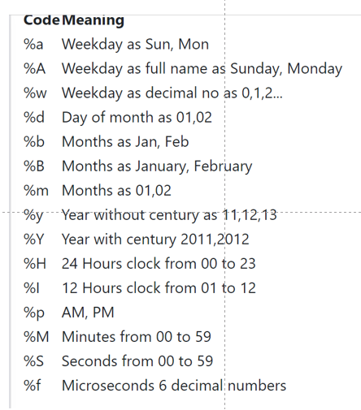

```python
#Another Example : When there is any character
try_this = "jan 20 2090; 4pm"
```

```python
datetime.strptime(try_this, '%b %d %Y; %I%p')
```

```
datetime.datetime(2090, 1, 20, 16, 0)
```

### Even better : dateutil

```python
!pip show python-dateutil
```

```
Name: python-dateutil
Version: 2.8.1
Summary: Extensions to the standard Python datetime module
Home-page: https://dateutil.readthedocs.io
Author: Gustavo Niemeyer
Author-email: gustavo@niemeyer.net
License: Dual License
Location: c:\users\aisha\anaconda3\lib\site-packages
Requires: six
Required-by: pandas, matplotlib, jupyter-client, datetime-distance, bokeh, anaconda-client, alembic
```

```python
from dateutil import parser
```

using parser we could very easily convert text to dates without needing to define the structure of the date

```python
parser.parse('jan 21st 1990')
```

```
datetime.datetime(1990, 1, 21, 0, 0)
```

```python
parser.parse('22 april 2068 at 4pm and 17 minutes 20 seconds')
```

```
datetime.datetime(2068, 4, 22, 16, 17, 20)
```

```python
parser.parse('jan 21st 1990').day
```

```
21
```

### the strftime() method

#### - This stands for string format time

```python
datetime.now()
```

```
datetime.datetime(2023, 1, 10, 22, 50, 15, 297969)
```

```python
dt = datetime.now()
```

```python
dt
```

```
datetime.datetime(2023, 1, 13, 15, 57, 28, 780193)
```

```python
#Let try to condense this datetime into a single year
dt.strftime('%Y')
```

[output not shown]

- We are capturing year and discarding or losing everything else

```python
#Another string representation of the same date
dt.strftime('Year : %Y; Month : %m ; Day : %d')
```

[output not shown]

```python
#Another string representation of the same date is
dt.strftime('Year : %Y; Month : %m ; Day : %d')
```

```
'Year : 2023; Month : 01 ; Day : 13'
```

#### More efficient code

You can refer to the format codes that represent both : Stringformat (strftime()) and string parse time (strptime())

```python
dt
```

```
datetime.datetime(2023, 1, 13, 15, 57, 28, 780193)
```

```python
dt.strftime('%c')
```

```
'Fri Jan 13 15:57:28 2023'
```

```python
dt.strftime('%c')
```

[output not shown]

```python
#An Alternative Approach
```

```python
"My data is {:%c}"
```

```
'My data is {:%c}'
```

```python
"My date is {:%c}".format(dt)
```

[output not shown]

This is how we convert datetime to Strings in Python

### The Numpy datetime64 Object

### Performant datetimes with Numpy

https://www.udemy.com/course/the-ultimate-pandas-bootcamp-advanced-python-data-analysis/learn/lecture/19342416#questions/13647656

Lets create a new datetime object

```python
import numpy as np
import pandas as pd
```

```python
#Instead of a Python datetime , we are now looking at the numpy datetime64 object
np.datetime64('2020-03-04')
```

```
numpy.datetime64('2020-03-04')
```

```python
#Instead of a Python datetime , we are now looking at the numpy datetime64 object
np.datetime64('2020-03-04')
```

```
numpy.datetime64('2020-03-04')
```

```python
a = np.datetime64('2020-03-04')
```

```python
#Creating another datetime object
b = np.datetime64(datetime.now())
```

```python
b
```

[output not shown]

- Now we have two datetime objects
- Now we can conduct operations on them

```python
a
```

```
numpy.datetime64('2020-03-04')
```

```python
#Starting with 'a' ('2020-03-04') , lets add 10 days
#day 4 has become 14
a + 10
```

```
numpy.datetime64('2020-03-14')
```

```python
b
```

```
numpy.datetime64('2023-01-10T22:54:57.556694')
```

```python
#Lets try to add 10 to "b = np.datetime64(datetime.now())" , capturing 12th of December
#numpy.datetime64('2022-12-12T07:52:02.666518')
#If we add 10 to b , we get the same datetime back
b + 10
```

```
numpy.datetime64('2023-01-10T22:54:57.556704')
```

Since b has a microsecond time unit , we just see some microseconds change

- because microseconds was the lowest precision here , we see the change in microseconds

We could change the time unit by Re-scaling the numpy datetime

- If we want to Re-scale our datetime "b" to have a daily timescale

```python
b
```

```
numpy.datetime64('2023-01-10T22:54:57.556694')
```

```python
b = np.datetime64(b , 'D')
```

```python
b
```

```
numpy.datetime64('2023-01-10')
```

- "D" is for day
- And we have a Re-scaled datetime ---> "T22:54:57.556694" is gone

```python
#And now if we add 10 to this
b + 10
```

```
numpy.datetime64('2023-01-20')
```

#### The power of this numpy datetime approach is ,it allows us to perform efficient vectorized operations on collections of dates.

```python
#Lets say we have an array of dates
np.array([
    '2019-02-20',
    '2019-06-20',
    '2090-03-23'
], dtype = np.datetime64)
```

```
array(['2019-02-20', '2019-06-20', '2090-03-23'], dtype='datetime64[D]')
```

```python
x='2019-02-20'
```

```python
np.datetime64(x)
```

```
numpy.datetime64('2019-02-20')
```

```python
#Lets say we have an array of dates
#and we specify the dtype to be "np.datetime64" so that Numpy parses this date for us
np.array([
    '2019-02-20',
    '2019-06-20',
    '2090-03-23'
], dtype = np.datetime64)
```

```
array(['2019-02-20', '2019-06-20', '2090-03-23'], dtype='datetime64[D]')
```

```python
dates = np.array([
    '2019-02-20',
    '2019-06-20',
    '2090-03-23'
], dtype = np.datetime64)
```

```python
#Subtract 10 days from each date in the Array
dates - 10
```

```
array(['2019-02-10', '2019-06-10', '2090-03-13'], dtype='datetime64[D]')
```

- And this is happening in a vectorized fashion

#### More Complicated Calculations with Numpy

```python
#Get the 10th previous Business date for all the dates in the Array
#This below function primarily calculates Business days
#offsets = -10 ::::Meaning , 10 previous days before
#roll = 'backward' :::: Let say this operation falls on a holiday
#This below function primarily calculates Business days, but what if it falls on a holiday
#In such situation , do we want to go backward or forward
#In this case the roll parameter specifies that we want to go backward
```

```python
dates
```

```
array(['2019-02-20', '2019-06-20', '2090-03-23'], dtype='datetime64[D]')
```

```python
np.busday_offset(dates, offsets = -10 , roll= 'backward')
```

```
array(['2019-02-06', '2019-06-06', '2090-03-09'], dtype='datetime64[D]')
```